# Impacts of selective logging management on butterflies in the Amazon - ScienceDirect

[figure not shown]

[figure not shown]

[figure not shown]

## Extras (1)

1. Supplementary material

## [Biological Conservation](https://www.sciencedirect.com/science/journal/00063207)

[Volume 225](https://www.sciencedirect.com/science/journal/00063207/225/supp/C), September 2018, Pages 1-9

# Impacts of selective logging management on butterflies in the Amazon

[GabrielaMontejo-Kovacevich<sup>a</sup>](https://www.sciencedirect.com/science/article/pii/S0006320718304142#!)[Matthew G.Hethcoat<sup>b</sup>](https://www.sciencedirect.com/science/article/pii/S0006320718304142#!)[Felix K.S.Lim<sup>a</sup>](https://www.sciencedirect.com/science/article/pii/S0006320718304142#!)[Charles J.Marsh<sup>c</sup>](https://www.sciencedirect.com/science/article/pii/S0006320718304142#!)[DayanaBonfantti<sup>d</sup>](https://www.sciencedirect.com/science/article/pii/S0006320718304142#!)[Carlos A.Peres<sup>e</sup>](https://www.sciencedirect.com/science/article/pii/S0006320718304142#!)[David P.Edwards<sup>a</sup>](https://www.sciencedirect.com/science/article/pii/S0006320718304142#!)

https://doi.org/10.1016/j.biocon.2018.06.012[Get rights and content](https://s100.copyright.com/AppDispatchServlet?publisherName=ELS&contentID=S0006320718304142&orderBeanReset=true)

## Highlights

**•**

Local selective logging intensity is a very good predictor of butterfly community composition in tropical forests.

**•**

Local-scale logging intensities are used to model responses to a range of strategies.

**•**

A mix of logging strategies and intensities may protect the most butterfly species.

**•**

Protecting some primary forest in logging concessions is key to biodiversity conservation.

## Keywords

Selective logging

Amazon

Butterflies

Disturbance

Land-sharing

Land-sparing

Reduced impact logging

## 1. Introduction

Selective logging for [timber production](https://www.sciencedirect.com/topics/earth-and-planetary-sciences/forestry-production) is a major driver of tropical forest degradation. With the exception of the Amazon and Papua New Guinea, selectively logged forest is now more widespread than old-growth [primary forest](https://www.sciencedirect.com/topics/agricultural-and-biological-sciences/primary-forests) (Edwards et al., 2014a), with 400 million hectares of rainforests now designated for timber production, an area more than twice the size of Mexico (Blaser et al., 2011). A key question is how to reconcile the burgeoning [logging industry](https://www.sciencedirect.com/topics/earth-and-planetary-sciences/logging-industry), in Amazonia and elsewhere, with biodiversity protection at a minimal opportunity cost.

Selective logging is a relatively low impact [land-use change](https://www.sciencedirect.com/topics/earth-and-planetary-sciences/land-use-change) compared to, for example, conversion to agricultural or pasture land, as it retains [species richness](https://www.sciencedirect.com/topics/earth-and-planetary-sciences/species-richness) across many taxa (Edwards et al., 2014a). Research into the impacts of selective logging in the Amazon has revolved around improving harvesting practices with Reduced Impact Logging (RIL) schemes, which do not directly target logging intensities but focus instead on reducing collateral damage (Putz et al., 2008; Bicknell et al., 2015). Nonetheless, changes in species abundance and composition do occur with higher logging intensities (Bicknell et al., 2014) indicating the need for rigorous field studies that specifically incorporate logging intensity to identify management strategies that will minimise biodiversity losses from selective logging (França et al., 2017).

The impacts of logging intensity can be detected at two levels: (1) on overall diversity and community composition; and (2) on individual species' abundance-yield relationships. The latter underpins whether land-sharing logging, in which a whole concession is logged at a low intensity, or land sparing that protects one or several blocks of unlogged primary forest while logging the rest of the concession at higher intensity is the optimal strategy. To our knowledge, only one field study has examined the impacts of using measures of logging intensity that ranged from local (averaged across 10 ha) to large-scale (averaged across 90 ha), and found that only measures of local logging intensity explain overall changes in dung beetle community post-logging (França et al., 2017). However, this study lacked an analysis of individual species' responses. Thus, understanding how fine-scale local logging intensity measures affect community composition metrics and individual species remains a timely frontier.

In turn, no study explicitly considers individual species' responses to logging intensity, yet such understanding is critical for assessing land-sparing versus land-sharing logging (Edwards et al., 2014a). The only empirical study to date in Borneo, Southeast Asia, found that land sparing was best for birds, ants and dung beetles (Edwards et al., 2014b), with approximately twice the number of species that were winners (i.e. had higher abundances) from sparing than from sharing, resulting in higher projected species richness under sparing than sharing. However, this study did not construct detailed species' abundance-yield relationships because it used a single ‘averaged’ logging intensity value for all high intensity plots and one for all low intensity plots. Applying an average intensity overlooks the important fine-scale local impacts of logging on forest structure, which determine species responses to logging intensity at small geographical scales, at which individuals interact with their environment and could thus lead to spurious inferences on the relative merits of land-sharing and land-sparing logging for biodiversity conservation.

Here, we address these issues by explicitly comparing butterfly community and individual species' responses to logging intensity, and then apply this understanding to simulations of land-sharing and land-sparing logging to estimate how many species would increase in abundance, i.e. winner species, under either strategy. We do so in Rondônia, south-western Brazilian Amazon, a region thought to host the highest butterfly local diversity on Earth (Emmel and Austin, 1990). Despite being [flagship species](https://www.sciencedirect.com/topics/agricultural-and-biological-sciences/flagship-species) for conservation in [temperate zones](https://www.sciencedirect.com/topics/agricultural-and-biological-sciences/temperate-zones), butterfly responses to the growing threat of selective logging remain largely unknown in the tropics (Lewis, 2001; Bonebrake et al., 2010), yet Brazil represents the third biggest producer of tropical wood worldwide (ITTO, 2016). We sampled butterflies along a gradient of known logging intensities in a concession practicing RIL techniques, and examined butterfly communities post-logging. We then used methods comparable to those in previous studies on land sharing versus sparing in an agricultural context (Phalan et al., 2011; Hulme et al., 2013; Gilroy et al., 2014) to model individual species responses to a range of hypothetical logging regimes that ultimately yield the same amount of timber. Finally, we examine whether logging regime preference is phylogenetically conserved among the studied butterfly clades.

## 2. Materials and methods

### 2.1. Study area

The study was based in the 46,184-hectare logging concession inside the Jamari [National Forest](https://www.sciencedirect.com/topics/agricultural-and-biological-sciences/national-forests), Rondônia, Brazil. The southern concession is managed by AMATA Brasil SA, which has been Forest Stewardship Council (FSC) certified since 2010. As part of their RIL strategy, all timber trees >40 cm in trunk diameter within the designated logging units are digitally mapped and measured prior to logging. In addition, several silvicultural techniques such as road planning, pre-felling vine cutting, and directional felling by highly trained operators are implemented. Records of the commercial yield of harvested trees are carefully kept by the company, enabling us to obtain logging intensity data within small patches of forest.

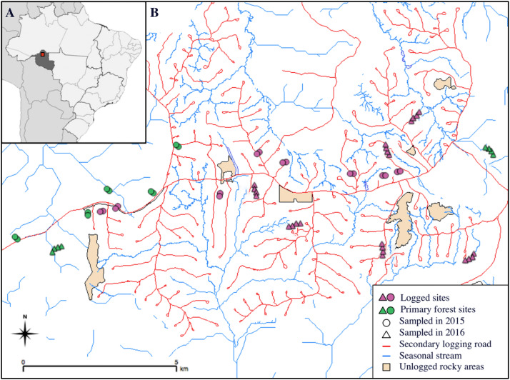

1. [Download : Download high-res image (1MB)](https://ars.els-cdn.com/content/image/1-s2.0-S0006320718304142-gr1_lrg.jpg)
2. [Download : Download full-size image](https://ars.els-cdn.com/content/image/1-s2.0-S0006320718304142-gr1.jpg)

Fig. 1. Map with locations of study areas. A) Map of Brazil with the region of Rondonia highlighted in dark grey and the approximate concession location in red. B) Green symbols represent [primary forest](https://www.sciencedirect.com/topics/agricultural-and-biological-sciences/primary-forests) sites and pink symbols are logged sites. Circles correspond to collection sites sampled in 2015 and triangles in 2016. Red lines are secondary abandoned logging roads, blue represent streams, and the black outlined boxes are rocky areas of closed-canopy forest where logging is not feasible. Location: Floresta Nacional do Jamari, Rondonia. (For interpretation of the references to color in this figure legend, the reader is referred to the web version of this article.)

### 2.2. Butterfly sampling

Each pre-selected site consisted of three baited traps, placed 15–25 m apart from one another. Traps were suspended from the nearest tree branch available 1 m above the ground, and vines and dense undergrowth within a 2-m radius were cleared to standardise trap accessibility for butterflies. We sampled fruit-feeding butterflies (Nymphalidae) using Van SomerenRydon cylindrical traps (Hughes et al., 1998), which were baited with a standardised mixture of mashed bananas and [sugarcane juice](https://www.sciencedirect.com/topics/agricultural-and-biological-sciences/sugarcane-juice) that had been left in the sun fermenting in closed containers for 12 h. The butterflies captured in each site are assumed to represent the community in a 50-m radius forest surrounding it, based on the very low turnover rate observed between sites in this study (SOM, Note S2) and recent literature showing that Neotropical [Nymphalidae](https://www.sciencedirect.com/topics/agricultural-and-biological-sciences/nymphalidae) butterflies are mostly influenced by their immediate surroundings (Ribeiro et al., 2012).

Butterflies have a strong vertical stratification in tropical forests (Ribeiro et al., 2016), and studies have shown that sampling canopy species is only needed when creating species inventories but not for assessing the impacts of anthropogenic disturbance (Dumbrell and Hill, 2005; Ribeiro and Freitas, 2012). We exclusively sampled understorey communities where bait-trapping has been shown to be more effective for most tribes than in the canopy strata (Whitworth et al., 2018), and because traps in logged sites with few tall canopies left can be hard to place (Dumbrell and Hill, 2005). Nevertheless, to test any potential differences in their responses, we present separate analyses for the understorey and canopy/open-habitat species in the SOM (Note S3, Figs. S4, S5).

### 2.3. Statistical analyses

#### 2.3.1. Butterfly assemblage responses to logging intensity

We use generalized additive models (GAMs) to assess overall changes in species abundance and richness with increasing logging intensity. GAMs are an extension of generalized linear models (GLMs) in which the assumption of a linear relationship between the continuous predictor and the response variable is relaxed (Guisan et al., 2002). We used GAMs over GLMs as they are a more flexible approach that makes fewer pre-modeling assumptions about the characteristics of the data. GAMs are particularly useful for studies looking at relationships between abundance and environmental variables since these are likely to be non-linear and complex (Knape, 2016; França et al., 2017). We fitted GAMs with a Poisson error and log-link function with a penalised regression smoother to limit the degree of higher order terms in the model, as abundance-yield curves might exhibit a quadratic or cubic effect, but higher order polynomial functions can overfit models and result in unrealistic predictions of abundance. Thus, we fitted two GAMs, one with species abundance and another with species richness as dependent variables, and both with logging intensity as a continuous predictor variable. The butterfly communities sampled within each habitat type, primary and logged forest, were shown to be geographically independent (Note S1, Fig. S2), which allowed for the exclusion of a [geographical distribution](https://www.sciencedirect.com/topics/agricultural-and-biological-sciences/geographical-distribution) term in our models.

We standardised species richness and abundance over 48-h periods to account for stochastic variation in sampling effort between sites. We used non-metric multidimensional scaling (NMDS) based on Bray-Curtis community dissimilarity to test for differences in species composition between primary and logged forest sites and permutational [multivariate analysis](https://www.sciencedirect.com/topics/agricultural-and-biological-sciences/multivariate-analysis) to quantify these. We tested the relative contributions of logging intensity for explaining the variance shown in NMDS analyses, specifying a [Restricted Maximum Likelihood](https://www.sciencedirect.com/topics/agricultural-and-biological-sciences/restricted-maximum-likelihood) criterion. In addition, to test for completeness of sampling and butterfly community independence across our sites, we performed rarefied sample-based species accumulation curves and carried out Mantel's spatial autocorrelation tests, as well as plotted species composition dissimilarity against spatial distance between sites (SOM, Note S1, Figs. S1 and S2). All statistical analyses were performed in R version 3.2.2 (R Core Team, 2016) using *mgvc* (Wood, 2001) to fit the gams and *vegan* (Oksanen et al., 2013) for diversity analyses.

#### 2.3.2. Fitting individual species abundance - logging yield curves

To understand species-level responses to increasing logging yield we fitted GAMs relating abundance of each butterfly species to logging intensity across the 40 sampled logged sites. Because butterfly community assemblages differed significantly between primary and logged forest sites, we only included logged sites in individual species abundance - logging yield curves. GAMs will automatically select a linear model when it represents a better fit than a polynomial model (Wood, 2001), in a similar way that density-yield curve model selection takes place in the agricultural sharing/sparing literature (Phalan et al., 2011). We only fitted models for species found in at least three sites, which resulted in the removal of 43.1% (69/160) of all species sampled. As a result, we fitted 91 GAMs with individual species abundance as the dependent variable and logging yield (in volume, m<sup>3</sup>) as the continuous predictor. We used these fitted models to predict butterfly abundances of these species at different logging intensities, and ultimately, to simulate a range of logging scenarios.

#### 2.3.3. Simulating land-sparing versus land-sharing scenarios

To simulate land-sharing and land-sparing scenarios, we created five hypothetical logging concessions with a range of logging intensities. All scenarios were made up of four forest units, each equivalent to the size of our sites (1.77 ha), to highlight the local-scale nature of our analyses. Total timber extraction in each 7.08 ha concession was set to 80 m<sup>3</sup> (11.3 m<sup>3</sup>/ha), which equates to an average of two canopy trees removed per hectare, a typical timber yield for RIL concessions in South America, and lower than mean intensity across our sampling sites. The minimum logging yield assigned to a unit was 10 m<sup>3</sup>/unit, which is approximately one tree per hectare. The maximum logging yield at any given hypothetical unit was 40 m<sup>3</sup>/unit, which represents the maximum logging yield of most of the concessions where our sites are located and falls within the 30 m<sup>3</sup>/ha legal limit in Brazil. The four units in each hypothetical scenario were assigned a land-use type that ranged from protected primary forest to logging at the maximum permissible yield, 40 m<sup>3</sup>/unit. The target yield could be achieved by any combination of yields per unit area as long as they were within the minimum and the maximum permissible yield. We selected the five most representative hypothetical concessions along the range from most land-sharing to most land-sparing logging scenarios (Fig. 2).

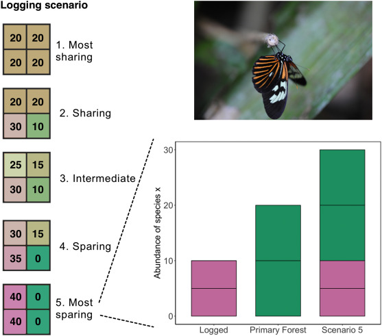

1. [Download : Download high-res image (446KB)](https://ars.els-cdn.com/content/image/1-s2.0-S0006320718304142-gr2_lrg.jpg)
2. [Download : Download full-size image](https://ars.els-cdn.com/content/image/1-s2.0-S0006320718304142-gr2.jpg)

Fig. 2. Hypothetical concessions under different logging regimes, ranging from the most land-sharing (1) to the most land-sparing (5), made up of four units. Numbers in each unit indicate logging intensity as volume of timber extracted in m<sup>3</sup> (unit size = 1.77 ha). The panel on the right shows how the total abundance of a species is calculated. In this example, for scenario 5 in which 50% of the hypothetical concession is logged at 40 m<sup>3</sup>/unit and the other half is protected [primary forest](https://www.sciencedirect.com/topics/agricultural-and-biological-sciences/primary-forests), the total abundance of a species is given by twice its predicted abundance at 40 m<sup>3</sup>/unit plus twice its predicted abundance in primary forest.

Total abundance of individual species in each logging scenario was calculated by adding up the predicted abundance in each of the four units. Abundance in logged units was predicted from the abundance – logging yield curves, and in primary forest units from the mean abundance in primary forest sites (Fig. 2), following a similar method to recent literature on agricultural land-sharing/sparing (Williams et al., 2017). We compared species abundances between land-sharing (scenarios 1 and 2) and land-sparing (scenarios 4 and 5) logging (Fig. 2). Individual species were then classified according to which scenario they were predicted to have the highest overall abundance in, i.e. whether they were ‘land-sharing winners’ or ‘land-sparing winners’. Species with <10% change in abundance were considered “equal” across strategies. We calculated the percentage increase in abundance with respect to the worse strategy for all species to discern between marginal and substantial changes. To compare species responses to all five logging scenarios, we calculated the percentage increase in abundance under scenarios 2–5 with respect to the most land-sharing logging scenario (scenario 1, Fig. 2).

To examine whether logging strategy preferences were phylogenetically conserved among closely related species, we constructed a genus-level [phylogeny](https://www.sciencedirect.com/topics/agricultural-and-biological-sciences/cladistics) using the *phyloGenerator* package (Pearse and Purvis, 2013) with automatically obtained [cytochrome oxidase](https://www.sciencedirect.com/topics/agricultural-and-biological-sciences/cytochrome-c-oxidase) one (COI) sequences from representative species in each genus. The resulting genus-level phylogeny was converted into a species-level tree by adding species branches, although eleven species were not plotted due to lack of data. To test for a phylogenetic signal of logging strategy preference we used the autocorrelation test Abouheif's C<sub>mean</sub> with 999 [permutations](https://www.sciencedirect.com/topics/earth-and-planetary-sciences/permutation) using *ade4* (Chessel et al., 2004).

## 3. Results

### 3.1. Butterfly assemblage responses to selective logging

#### 3.1.1. Primary forest vs. logged forest assemblages

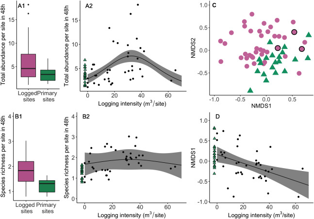

1. [Download : Download high-res image (430KB)](https://ars.els-cdn.com/content/image/1-s2.0-S0006320718304142-gr3_lrg.jpg)
2. [Download : Download full-size image](https://ars.els-cdn.com/content/image/1-s2.0-S0006320718304142-gr3.jpg)

Fig. 3. Butterfly community responses to selective logging. Logged sites are shown in pink and [primary forest](https://www.sciencedirect.com/topics/agricultural-and-biological-sciences/primary-forests) sites in green. Grey shaded areas and error bars represent 95% confidence intervals of the means. Abundances and [species richness](https://www.sciencedirect.com/topics/earth-and-planetary-sciences/species-richness) are averaged per site for a 48 h period. Green triangles represent values for primary sites, not included in the models. A1. Total abundance of butterflies captured per site. A2. Fitted GAM model of butterfly abundance in logged sites only (black circles) against logging intensity defined as volume of timber extracted per site. B1. Species richness per site. B2. Fitted GAM model of species richness in logged sites only (black circles) against logging intensity. C. Non-Metric Multidimensional Scaling (NMDS) ordination representing Bray-Curtis distances of butterfly community assemblages in primary (triangles) and logged (circles) sites (Stress = 0.19). Circles with black borders indicate logged sites with 0 trees logged within the sampling site. D. NMDS axis 1 scores for logged sites with a GAM fitted model against logging intensity (m<sup>3</sup>/site) (R<sup>2</sup> = 0.24, deviance explained = 25.4%, p < 0.001). (For interpretation of the references to color in this figure legend, the reader is referred to the web version of this article.)

#### 3.1.2. Butterfly assemblage responses to logging intensity

Butterfly abundance was highest at intermediate logging intensities, with some evidence of a decrease when timber extraction exceeded 40 m<sup>3</sup> of timber per site, (R<sup>2</sup> = 0.2, deviance explained = 25.8%, *p* < 0.001) (Fig. 3A2). Overall species richness in logged sites did not change with increasing logging intensity (R<sup>2</sup> = 0.1, deviance explained = 11.6%, *p* = 0.2) (Fig. 3B2). However, local logging intensity was a very good predictor of both overall community composition variance (R<sup>2</sup> = 0.39, deviance explained = 43.9%, p < 0.001, Fig. 3C), and of changes to community composition across logged sites (as defined by NMDS axis 1) (R<sup>2</sup> = 0.24, deviance explained = 25.4%, p < 0.001, Fig. 3D).

### 3.2. Butterfly responses to hypothetical logging scenarios

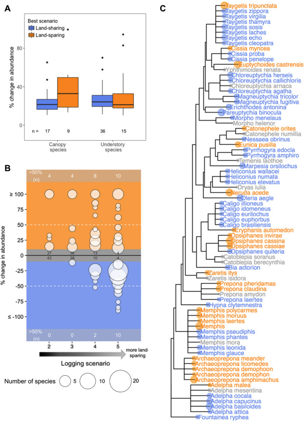

1. [Download : Download high-res image (633KB)](https://ars.els-cdn.com/content/image/1-s2.0-S0006320718304142-gr4_lrg.jpg)
2. [Download : Download full-size image](https://ars.els-cdn.com/content/image/1-s2.0-S0006320718304142-gr4.jpg)

#### 3.2.2. Species responses across logging strategies

More species were predicted to have higher abundances in any of the intermediate scenarios than in the most land-sharing scenario (Fig. 4B). As shown by logging scenario 2, a small step towards a more land-sparing strategy increased the abundance of four species by >50%, when compared to the land-sharing baseline (Fig. 4B). However, while some species clearly benefited from stepping away from an extreme land-sharing logging approach (i.e. those species in the top orange panel), a considerable number of species decreased in abundance as we compared against more extreme land-sparing logging (i.e. species in the bottom blue panel). This suggests a potential “land-sparingness” threshold above which many species would struggle (scenario 5, Fig. 4B): these species would benefit from a mix of land-sharing intermediate strategies over extreme land-sparing logging. We found a significant [phylogenetic](https://www.sciencedirect.com/topics/agricultural-and-biological-sciences/cladistics) signal for land-sharing vs. land-sparing logging strategy preference (C<sub>mean</sub> = 0.14, *p* = 0.03, Fig. 4C), although within speciose genera some discrepancies arise. Species in some tribes, such as Satyrini or Limentidini, were predicted to have consistently higher abundance in land-sharing strategies, whereas Preponini butterflies, for example, seem to perform better in land-sparing logging scenarios (Fig. 4C). It is important to note that 16 out of 18 species that were found exclusively in primary forests were excluded from the land-sharing/sparing analyses because they did not meet the occurrence criteria, but these rare species are predicted to benefit from land-sparing logging.

## 4. Discussion

Selective logging affects vast areas of the tropics, and there is clearly a need to devise strategies that minimise its impacts and reconcile selective logging with biodiversity conservation. Focusing on butterflies in the south-west Amazon, we examined these impacts at two levels: on the overall species abundance, richness, and composition post-logging, and on how logging intensity affects individual species' abundance-yield relationships. We found that local logging intensity has an effect on butterfly abundance, but not on overall [species richness](https://www.sciencedirect.com/topics/earth-and-planetary-sciences/species-richness), and that changes in species community composition post-logging can be explained by local logging intensity levels (Fig. 3). Individual species performed differently under a range of logging strategies, with a majority having higher abundance in low-intensity land-sharing logging simulations than in extreme land-sparing scenarios. Nevertheless, some butterfly clades performed disproportionally better under land-sparing logging scenarios, highlighting that some forest-sensitive species may require patches of protected [primary forest](https://www.sciencedirect.com/topics/agricultural-and-biological-sciences/primary-forests) for their persistence within selectively-logged concessions (Fig. 4). Our results underline the need to consider the impacts of local-scale logging intensity on communities and individual species, and we present a method by which we can use this knowledge to examine the impacts of landscape-level planning of timber extraction that retains blocks of low disturbance or primary forest for biodiversity conservation.

### 4.1. Assemblage responses to selective logging intensity

Our study found very similar effects of selective logging on butterfly communities to previous studies (Ribeiro and Freitas, 2012). The increased butterfly abundance in logged forest, particularly at intermediate logging intensities, could be due to generalist species benefiting from the lack of vertical stratification after logging (Koh, 2007; Barlow et al., 2007; Ribeiro et al. 2015). The lack of changes in overall species richness with logging intensity can be explained by the replacement of forest sensitive species with more generalist ones (canopy/open-habitat) post-logging, as suggested by changes in community assemblage and the overrepresentation of canopy/open-habitat species we found in logged sites (SOM, Fig. S5). Species composition changed dramatically between unlogged and selectively logged forest, especially at higher logging intensities, probably as a result of the change in [understorey](https://www.sciencedirect.com/topics/earth-and-planetary-sciences/understory) vegetation and the lack of shade in highly disturbed sites, which can displace typical understorey species. Furthermore, we found, for the first time, that local-scale logging intensity was a very good predictor of butterfly community changes, which highlights the importance of considering logging yield when predicting species responses to selective logging, as suggested by other studies (Burivalova et al., 2014; França et al., 2017).

### 4.2. Land-sharing vs. land-sparing logging

Our study is the first that, by incorporating fine-scale logging intensity records, creates predictions of species responses under a range of different management scenarios (following methods developed for agricultural habitat conversion; Phalan et al., 2011). We did not find land-sparing logging significantly more effective for butterfly conservation than land-sharing logging, as found by Edwards et al. (2014b) for Bornean birds, ants and dung beetles using simulations that contrasted sharing and sparing at fixed logging intensities averaged across thousands of hectares. Because we have used within-block variation in logging intensity, the results of our assessment are at a more localised scale than those typically considered by logging companies (e.g., 10 ha França et al., 2016), and in doing so we can assess logging impacts at the scale they affect individuals. By setting a realistic average logging intensity across our scenarios (11.3 m<sup>3</sup>/ha) and an upper-limit to logging intensity per unit within the realms of RIL (22.6 m<sup>3</sup>/ha), our simulations concluded that intermediate strategies favoured higher butterfly species richness than extreme land-sharing or land-sparing strategies. We found some evidence for a logging intensity threshold (~20 m<sup>3</sup>/ha) above which land-sparing scenarios become detrimental for many butterfly species (Fig. 4B).

Preference for land-sharing or land-sparing logging strategies was phylogenetically conserved in our results. This again suggests that a mix of strategies is needed to conserve the majority of species, and provides support that the data and modeling approaches developed here are appropriate. In addition, 18 species were found exclusively in primary forest, 16 of which were rare, i.e. found in less than three sites, and were thus excluded from our land-sharing/sparing modeling. These species should be land-sparing winners as they require a patch of protected primary forest to persist. Our results may not mirror the responses of other taxa with different disturbance tolerances, life histories, or dispersal abilities, and butterflies have not been shown to be perfect indicators of patterns in other groups (Bonebrake et al., 2010). Thus examining this issue for other taxa is a key frontier, with the land-sharing vs. land-sparing modeling approach that we have developed in this study easily applicable to other datasets. If accurate range maps to define [endemic species](https://www.sciencedirect.com/topics/earth-and-planetary-sciences/endemic-species) or an IUCN Red-list assessment were available, we could have used our modeling approach to determine how logging intensity affects these species and thus whether land-sparing or sharing logging would best protect species of particular conservation interest. Such assessments focusing on species of high conservation priority are critical for a range of taxa.

Land-sharing logging also has risks associated with it. Perhaps least understood is the increased incidental damage incurred when harvesting trees over a larger area, including from a larger network of roads and skid trails to reach the desired trees. More roads also increase the risk of secondary collateral effects, such as illegal logging and hunting, that can potentially double the biodiversity loss expected from deforestation alone (Barlow et al., 2016). The conservation benefits of land-sharing logging are also highly dependent on the surrounding habitat quality, in particular if primary forests act as sources of lost species (Gilroy and Edwards, 2017), as has been shown in the agricultural land-sharing/sparing debate (Lamb et al., 2016). In the region where this study took place, for instance, >30% of forest-land has been converted to cattle farming in the last few decades, and most of what is left has been or will be selectively logged (Asner et al., 2009).

### 4.3. Study limitations

We only sampled fruit-feeding butterflies in the understorey. Fruit-feeding butterflies have often been used to examine the impacts of [land-use change](https://www.sciencedirect.com/topics/earth-and-planetary-sciences/land-use-change) on biodiversity, as they are relatively easy to trap and identify, and they correlate with total butterfly species richness in many areas of the [Neotropics](https://www.sciencedirect.com/topics/earth-and-planetary-sciences/neotropics) (Bonebrake et al., 2010). Understorey sampling could incur a bias towards detecting higher diversity in disturbed sites, as canopy/open-habitat species are able to penetrate into the understorey due to [canopy gaps](https://www.sciencedirect.com/topics/agricultural-and-biological-sciences/canopy-gaps) from logging (Koh, 2007). However, recent studies using both canopy and understorey traps to assess the impacts of selective logging on butterflies concluded that their outcomes did not change when canopy data was excluded, and that the canopy assemblages maintained the same structure with selective logging (Dumbrell and Hill, 2005; Barlow et al., 2007; Ribeiro and Freitas, 2012). In addition, our study does not explicitly assess the optimal size and spatial arrangement of logged and primary forest blocks in logging concessions. Given the increasingly fragmented nature of primary tropical rainforests, this is an important question for future studies to tackle.

Our study predicts the abundance each species would have at different logging intensities and hypothetical logging scenarios. This method furthers our understanding of community responses to selective logging strategies, compared to previous studies that only used [permutations](https://www.sciencedirect.com/topics/earth-and-planetary-sciences/permutation) of species abundances in areas with averaged logging intensities (Edwards et al., 2014b), or that only assessed whole community responses to intensity (França et al., 2017). By allowing our models to behave non-linearly, we ensured that the best-fitted abundance-yield curves were obtained from the data in hand. Nevertheless, a common limitation of individual species assessments is that relatively large datasets are required, alongside detailed knowledge of logging yield, which are still rare in tropical ecosystems. It could be argued that our sites were logged too recently for the forest to have recovered (3–5 years prior to the study). However, several studies looking at the impacts of selective logging via RIL on butterflies (Ribeiro and Freitas, 2012; Ribeiro et al. 2015) and on other taxa (Azevedo-Ramos et al., 2006; Bicknell et al., 2015) have used sites that were logged less than three years before the study (e.g. 10 months post-logging in França et al., 2016, França et al., 2017). Only studies in Southeast Asia have examined longer-term impacts (e.g. Hamer et al., 2003; Koh, 2007), with the mechanized [logging industry](https://www.sciencedirect.com/topics/earth-and-planetary-sciences/logging-industry) having been much more prevalent in Asia than in Latin America. Thus, despite its limitations, our study represents the most complete assessment of the impacts of selective logging and its intensity on Neotropical butterflies to date, and is the first to successfully predict individual species responses to different logging strategies using accurate abundance-yield relationships. The methods developed here can be used for similar assessments in other taxa.

### 4.4. Implications for biodiversity conservation

Our results predict that logging at low intensity or protecting some blocks of primary forests in logging concessions in the Amazon can have significant conservation benefits for butterflies, although responses have been shown to greatly vary across groups. Many studies have recently acknowledged that primary forests are irreplaceable for sustaining tropical biodiversity (Gibson et al., 2011). In the context of selective logging, however, very few studies have considered the possibility of creating a mosaic of logged areas and primary or nearly undisturbed forest within logging concessions to protect their unique biodiversity (Ramage et al., 2013). Given the ever-growing demand for timber, especially in the Amazon, it is critical that studies focus on finding the best ways to manage, at a minimal opportunity cost, the areas that will be selectively logged. Future studies should assess whether areas of the forest that are less easy to harvest, such as rocky substrates, or those already protected by law, such as [riparian zones](https://www.sciencedirect.com/topics/agricultural-and-biological-sciences/riparian-zone), should be the targets for protection of undisturbed forest in logging concessions or whether to maximise biodiversity benefits other areas (i.e. flatter upland forest) would need to be included. This is particularly important for countries, such as Brazil, that are now in the process of designating vast forest concessions for logging, spanning millions of hectares, with no clear limits to local-scale logging intensities (i.e. 10-ha to 100-ha levels) or requirements to protect some areas of primary forest beyond legal restrictions preventing logging next to waterways (Edwards et al., 2014a).

Our results suggest that we must work with timber-producing nations and certification bodies to further study the impacts of varying local-scale logging intensity on biodiversity, and to ensure the retention of at least some primary forest blocks within logged forests, both as reservoirs of rare species and those imperiled by even low intensities of logging, which can use these blocks as sources for [re-colonisation](https://www.sciencedirect.com/topics/earth-and-planetary-sciences/recolonization) of logged forests as they recover structure over time. Finally, we need further research to understand the minimum viable patch size and optimal configuration of retained primary forest within logged landscapes. Failure to shift focus from the mere application of logging at low intensity across entire concessions could have severe negative consequences for a considerable number of sensitive forest-interior species.

## Data accessibility

Data and scripts are available on the public repository Zenodo (https://doi.org/10.5281/zenodo.1291658).

## Author contributions

G.M.K, D.P.E. and C.A.P. devised the study, G.M.K. and C.J.M. collected the data, and G.M.K and D.B. identified the butterflies and G.M.K, F.K.S.L., and M.G.H. analysed the data. G.M.K and D.P.E. led in writing the manuscript. All authors contributed critically and gave approval for publication.

## Acknowledgements

We would like to thank AMATA Brasil for providing timber yield data and access to their concession, and Matthew Linley and Márcia Michele de Souza Perdigão for invaluable field assistance. G.M.K. was supported by The University of Sheffield, The Explorers Club Youth Fund and The British Entomological and Natural History Society (Professor Hering Memorial Research Fund).

## Appendix A. Supplementary data

[Download : Download Word document (16MB)](https://ars.els-cdn.com/content/image/1-s2.0-S0006320718304142-mmc1.docx)

Supplementary material

## References

**Asner et al., 2009**

G.P. Asner, T.K. Rudel, T.M. Aide, R. DeFries, R. Emerson

**A contemporary assessment of change in humid tropical forests**

Conserv. Biol., 23 (6) (2009), pp. 1386-1395

[CrossRef](https://doi.org/10.1111/j.1523-1739.2009.01333.x)[View Record in Scopus](https://www.scopus.com/inward/record.url?eid=2-s2.0-70450253295&partnerID=10&rel=R3.0.0)Google Scholar

**Azevedo-Ramos et al., 2006**

C. Azevedo-Ramos, O. de Carvalho, B.D. do Amaral

**Short-term effects of reduced-impact logging on eastern Amazon fauna**

For. Ecol. Manag., 232 (1) (2006), pp. 26-35

[Article](https://www.sciencedirect.com/science/article/pii/S0378112706003215)[Download PDF](https://www.sciencedirect.com/science/article/pii/S0378112706003215/pdfft?md5=06d4810f9dd5fd1795a14209f710ee35&pid=1-s2.0-S0378112706003215-main.pdf)[View Record in Scopus](https://www.scopus.com/inward/record.url?eid=2-s2.0-33746290708&partnerID=10&rel=R3.0.0)Google Scholar

**Barlow et al., 2007**

J. Barlow, W.L. Overal, I.S. Araujo, T.A. Gardner, C.A. Peres

**The value of primary, secondary and plantation forests for fruit-feeding butterflies in the Brazilian Amazon**

J. Appl. Ecol., 44 (5) (2007), pp. 1001-1012

[CrossRef](https://doi.org/10.1111/j.1365-2664.2007.01347.x)[View Record in Scopus](https://www.scopus.com/inward/record.url?eid=2-s2.0-34548397318&partnerID=10&rel=R3.0.0)Google Scholar

**Barlow et al., 2016**

J. Barlow, G.D. Lennox, J. Ferreira, E. Berenguer, A.C. Lees, Nally R. Mac, J.R. Thomson, S. Frosini, D.B. Ferraz, J. Louzada, V. Hugo, F. Oliveira, L. Parry, R. Ribeiro, D.C. Solar, I.C.G. Vieira, L.E.O.C. Aragão, R.A. Begotti, R.F. Braga

**Anthropogenic disturbance in tropical forests can double biodiversity loss from deforestation**

Nature, 535 (2016), pp. 144-147

[CrossRef](https://doi.org/10.1038/nature18326)[View Record in Scopus](https://www.scopus.com/inward/record.url?eid=2-s2.0-84977637979&partnerID=10&rel=R3.0.0)Google Scholar

**Bicknell et al., 2014**

J.E. Bicknell, M.J. Struebig, D.P. Edwards, Z.G. Davies

**Improved timber harvest techniques maintain biodiversity in tropical forests**

Curr. Biol., 24 (23) (2014), pp. R1119-R1120, 10.1016/j.cub.2014.10.067

[Article](https://www.sciencedirect.com/science/article/pii/S0960982214014158)[Download PDF](https://www.sciencedirect.com/science/article/pii/S0960982214014158/pdfft?md5=9d95b83e1f115b8ddeb20205c225273c&pid=1-s2.0-S0960982214014158-main.pdf)[View Record in Scopus](https://www.scopus.com/inward/record.url?eid=2-s2.0-84919691125&partnerID=10&rel=R3.0.0)Google Scholar

**Bicknell et al., 2015**

J.E. Bicknell, M.J. Struebig, Z.G. Davies

**Reconciling timber extraction with biodiversity conservation in tropical forests using reduced-impact logging**

J. Appl. Ecol., 52 (2) (2015), pp. 379-388

[CrossRef](https://doi.org/10.1111/1365-2664.12391)[View Record in Scopus](https://www.scopus.com/inward/record.url?eid=2-s2.0-84924457247&partnerID=10&rel=R3.0.0)Google Scholar

**Blaser et al., 2011**

J. Blaser, A. Sarre, D. Poore, S. Johnson

**Status of tropical forest management 2011**

ITTO Technical Series, 38 (2011), p. 418

[Google Scholar](https://scholar.google.com/scholar_lookup?title=Status%20of%20tropical%20forest%20management%202011&publication_year=2011&author=J.%20Blaser&author=A.%20Sarre&author=D.%20Poore&author=S.%20Johnson)

**Bonebrake et al., 2010**

T.C. Bonebrake, L.C. Ponisio, C.L. Boggs, P.R. Ehrlich

**More than just indicators: a review of tropical butterfly ecology and conservation**

Biol. Conserv., 143 (8) (2010), pp. 1831-1841

[Article](https://www.sciencedirect.com/science/article/pii/S0006320710001904)[Download PDF](https://www.sciencedirect.com/science/article/pii/S0006320710001904/pdfft?md5=c0e46755683c6d1b17b70bb84be62324&pid=1-s2.0-S0006320710001904-main.pdf)[View Record in Scopus](https://www.scopus.com/inward/record.url?eid=2-s2.0-77954815397&partnerID=10&rel=R3.0.0)Google Scholar

**Burivalova et al., 2014**

Z. Burivalova, Ç.H. Şekercioğlu, L.P. Koh

**Thresholds of logging intensity to maintain tropical forest biodiversity**

Curr. Biol., 24 (16) (2014), pp. 1893-1898

[Article](https://www.sciencedirect.com/science/article/pii/S0960982214007829)[Download PDF](https://www.sciencedirect.com/science/article/pii/S0960982214007829/pdfft?md5=ae603248ff688a79f08917924a8b89dc&pid=1-s2.0-S0960982214007829-main.pdf)[View Record in Scopus](https://www.scopus.com/inward/record.url?eid=2-s2.0-84906306923&partnerID=10&rel=R3.0.0)Google Scholar

**Chessel et al., 2004**

D. Chessel, A.B. Dufour, J. Thioulouse

**The ade4 package-I-One-table methods**

R news, 4 (1) (2004), pp. 5-10

[View Record in Scopus](https://www.scopus.com/inward/record.url?eid=2-s2.0-85075548731&partnerID=10&rel=R3.0.0)[Google Scholar](https://scholar.google.com/scholar_lookup?title=The%20ade4%20package-I-One-table%20methods&publication_year=2004&author=D.%20Chessel&author=A.B.%20Dufour&author=J.%20Thioulouse)

**Dumbrell and Hill, 2005**

A.J. Dumbrell, J.K. Hill

**Impacts of selective logging on canopy and ground assemblages of tropical forest butterflies: implications for sampling**

Biol. Conserv., 125 (1) (2005), pp. 123-131

[Article](https://www.sciencedirect.com/science/article/pii/S0006320705001400)[Download PDF](https://www.sciencedirect.com/science/article/pii/S0006320705001400/pdfft?md5=dab8b3fa764703d159957c4b9a45daf1&pid=1-s2.0-S0006320705001400-main.pdf)[View Record in Scopus](https://www.scopus.com/inward/record.url?eid=2-s2.0-19444386429&partnerID=10&rel=R3.0.0)Google Scholar

**Edwards et al., 2014a**

D.P. Edwards, J.A. Tobias, D. Sheil, E. Meijaard, W.F. Laurance

**Maintaining ecosystem function and services in logged tropical forests**

Trends Ecol. Evol., 29 (9) (2014), pp. 511-520

[Article](https://www.sciencedirect.com/science/article/pii/S0169534714001542)[Download PDF](https://www.sciencedirect.com/science/article/pii/S0169534714001542/pdfft?md5=d5b97e91be4d138593ae1320a3fd8ea7&pid=1-s2.0-S0169534714001542-main.pdf)[View Record in Scopus](https://www.scopus.com/inward/record.url?eid=2-s2.0-84906069360&partnerID=10&rel=R3.0.0)Google Scholar

**Edwards et al., 2014b**

D.P. Edwards, J.J. Gilroy, P. Woodcock, F.A. Edwards, T.H. Larsen, D.J. Andrews, M.A. Derhé, T.D. Docherty, W.W. Hsu, S.L. Mitchell, T. Ota

**Land-sharing versus land-sparing logging: reconciling timber extraction with biodiversity conservation**

Glob. Chang. Biol., 20 (1) (2014), pp. 183-191

[CrossRef](https://doi.org/10.1111/gcb.12353)[View Record in Scopus](https://www.scopus.com/inward/record.url?eid=2-s2.0-84889662305&partnerID=10&rel=R3.0.0)Google Scholar

**Emmel et al., 1990**

T.C. Emmel, G.T. Austin, *et al.*

**The tropical rain forest butterfly Fauna of Rondonia, Brazil: species diversity and conservation**

Tropical Lepidoptera, 1 (1) (1990), p. 12

Google Scholar

**França et al., 2016**

F. França, J. Louzada, V. Korasaki, H. Griffiths, J.M. Silveira, J. Barlow

**Do space-for-time assessments underestimate the impacts of logging on tropical biodiversity? An Amazonian case study using dung beetles**

J. Appl. Ecol., 53 (4) (2016), pp. 1098-1105

[CrossRef](https://doi.org/10.1111/1365-2664.12657)[View Record in Scopus](https://www.scopus.com/inward/record.url?eid=2-s2.0-84978374717&partnerID=10&rel=R3.0.0)[Google Scholar](https://scholar.google.com/scholar?q=Do%20space-for-time%20assessments%20underestimate%20the%20impacts%20of%20logging%20on%20tropical%20biodiversity%20An%20Amazonian%20case%20study%20using%20dung%20beetles)

**França et al., 2017**

F.M. França, F.S. Frazão, V. Korasaki, J. Louzada, J. Barlow

**Identifying thresholds of logging intensity on dung beetle communities to improve the sustainable management of Amazonian tropical forests**

Biol. Conserv., 216 (2017), pp. 115-122

[Article](https://www.sciencedirect.com/science/article/pii/S0006320717311709)[Download PDF](https://www.sciencedirect.com/science/article/pii/S0006320717311709/pdfft?md5=66ed4176c5c90b10c6a1bd4b7681fae0&pid=1-s2.0-S0006320717311709-main.pdf)[View Record in Scopus](https://www.scopus.com/inward/record.url?eid=2-s2.0-85032684910&partnerID=10&rel=R3.0.0)Google Scholar

**Gibson et al., 2011**

L. Gibson, T.M. Lee, L.P. Koh, B.W. Brook, T.A. Gardner, J. Barlow, C.A. Peres, C.J. Bradshaw, W.F. Laurance, T.E. Lovejoy, N.S. Sodhi

**Primary forests are irreplaceable for sustaining tropical biodiversity**

Nature, 478 (7369) (2011), pp. 378-381

[CrossRef](https://doi.org/10.1038/nature10425)[View Record in Scopus](https://www.scopus.com/inward/record.url?eid=2-s2.0-80055015145&partnerID=10&rel=R3.0.0)Google Scholar

**Gilroy and Edwards, 2017**

J.J. Gilroy, D.P. Edwards

**Source-sink dynamics: a neglected problem for landscape-scale biodiversity conservation in the tropics**

Curr. Landsc. Ecol. Rep., 2 (1) (2017), pp. 51-60

[CrossRef](https://doi.org/10.1007/s40823-017-0023-3)[View Record in Scopus](https://www.scopus.com/inward/record.url?eid=2-s2.0-85034012283&partnerID=10&rel=R3.0.0)Google Scholar

**Gilroy et al., 2014**

J.J. Gilroy, F.A. Edwards, C.A. Medina Uribe, T. Haugaasen, D.P. Edwards

**Surrounding habitats mediate the trade-off between land-sharing and land-sparing agriculture in the tropics**

J. Appl. Ecol., 51 (5) (2014), pp. 1337-1346

(Wiley Online Library)

[CrossRef](https://doi.org/10.1111/1365-2664.12284)[View Record in Scopus](https://www.scopus.com/inward/record.url?eid=2-s2.0-84921817657&partnerID=10&rel=R3.0.0)Google Scholar

**Griscom et al., 2017**

B.W. Griscom, R.C. Goodman, Z. Burivalova, F.E. Putz

**Carbon and biodiversity impacts of intensive versus extensive tropical forestry**

Conserv. Lett., 11 (1) (2017), p. e12362

Google Scholar

**Guisan et al., 2002**

A. Guisan, T.C. Edwards, T. Hastie

**Generalized linear and generalized additive models in studies of species distributions: setting the scene**

Ecol. Model., 157 (2) (2002), pp. 89-100

[Article](https://www.sciencedirect.com/science/article/pii/S0304380002002041)[Download PDF](https://www.sciencedirect.com/science/article/pii/S0304380002002041/pdfft?md5=dd86d365641a68f266202802c18d8165&pid=1-s2.0-S0304380002002041-main.pdf)[View Record in Scopus](https://www.scopus.com/inward/record.url?eid=2-s2.0-0037202446&partnerID=10&rel=R3.0.0)Google Scholar

**Hamer et al., 2003**

K.C. Hamer, J.K. Hill, S. Benedick, N. Mustaffa, T.N. Sherratt, M. Maryati, V.K. Chey

**Ecology of butterflies in natural and selectively logged forests of northern Borneo: the importance of habitat heterogeneity**

J. Appl. Ecol., 40 (1) (2003), pp. 150-162

[View Record in Scopus](https://www.scopus.com/inward/record.url?eid=2-s2.0-0037328010&partnerID=10&rel=R3.0.0)Google Scholar

**Hughes et al., 1998**

J.B. Hughes, G.C. Daily, P.E. Ehrlich

**Use of fruit bait traps for monitoring of butterflies (Lepidoptera: Nymphalidae)**

Rev. Biol. Trop., 46 (3) (1998)

[Google Scholar](https://scholar.google.com/scholar?q=Use%20of%20fruit%20bait%20traps%20for%20monitoring%20of%20butterflies)

**Hulme et al., 2013**

M.F. Hulme, J.A. Vickery, R.E. Green, B. Phalan, D.E. Chamberlain, D.E. Pomeroy, D. Nalwanga, D. Mushabe, R. Katebaka, S. Bolwig, P.W. Atkinson

**Conserving the birds of Uganda's banana-coffee arc: land sparing and land sharing compared**

PLoS One, 8 (2) (2013), Article e54597

[CrossRef](https://doi.org/10.1371/journal.pone.0054597)[View Record in Scopus](https://www.scopus.com/inward/record.url?eid=2-s2.0-84873502832&partnerID=10&rel=R3.0.0)[Google Scholar](https://scholar.google.com/scholar?q=Conserving%20the%20birds%20of%20Ugandas%20banana-coffee%20arc:%20land%20sparing%20and%20land%20sharing%20compared)

**ITTO, 2016**

ITTO

http://www.itto.int/direct/topics/topics_pdf_download/topics_id=5194&no=1 (2016)

**Knape, 2016**

J. Knape

**Decomposing trends in swedish bird populations using generalized additive mixed models**

J. Appl. Ecol., 53 (6) (2016), pp. 1852-1861

(Wiley Online Library)

[CrossRef](https://doi.org/10.1111/1365-2664.12720)[View Record in Scopus](https://www.scopus.com/inward/record.url?eid=2-s2.0-84979055659&partnerID=10&rel=R3.0.0)[Google Scholar](https://scholar.google.com/scholar_lookup?title=Decomposing%20trends%20in%20swedish%20bird%20populations%20using%20generalized%20additive%20mixed%20models&publication_year=2016&author=J.%20Knape)

**Koh, 2007**

L.P. Koh

**Impacts of land use change on South-east Asian forest butterflies: a review**

J. Appl. Ecol., 44 (4) (2007), pp. 703-713

[CrossRef](https://doi.org/10.1111/j.1365-2664.2007.01324.x)[View Record in Scopus](https://www.scopus.com/inward/record.url?eid=2-s2.0-34347381299&partnerID=10&rel=R3.0.0)[Google Scholar](https://scholar.google.com/scholar_lookup?title=Impacts%20of%20land%20use%20change%20on%20South-east%20Asian%20forest%20butterflies%3A%20a%20review&publication_year=2007&author=L.P.%20Koh)

**Lamb et al., 2016**

A. Lamb, A. Balmford, R.E. Green, B. Phalan

**To what extent could edge effects and habitat fragmentation diminish the potential benefits of land sparing?**

Biol. Conserv., 195 (2016), pp. 264-271

[Article](https://www.sciencedirect.com/science/article/pii/S0006320716300064)[Download PDF](https://www.sciencedirect.com/science/article/pii/S0006320716300064/pdfft?md5=e5127e28c46670425b3e2db465aaa693&pid=1-s2.0-S0006320716300064-main.pdf)[View Record in Scopus](https://www.scopus.com/inward/record.url?eid=2-s2.0-84955622057&partnerID=10&rel=R3.0.0)[Google Scholar](https://scholar.google.com/scholar?q=To%20what%20extent%20could%20edge%20effects%20and%20habitat%20fragmentation%20diminish%20the%20potential%20benefits%20of%20land%20sparing)

**Lewis, 2001**

O.T. Lewis

**Effect of experimental selective logging on tropical butterflies**

Conserv. Biol., 15 (2) (2001), pp. 389-400

[View Record in Scopus](https://www.scopus.com/inward/record.url?eid=2-s2.0-0034914657&partnerID=10&rel=R3.0.0)[Google Scholar](https://scholar.google.com/scholar_lookup?title=Effect%20of%20experimental%20selective%20logging%20on%20tropical%20butterflies&publication_year=2001&author=O.T.%20Lewis)

**Oksanen et al., 2013**

J. Oksanen, F.G. Blanchet, R. Kindt, P. Legendre, P.R. Minchin, R.B. O'Hara, G.L. Simpson, P. Solymos, M.H.H. Stevens, H. Wagner, M.J. Oksanen

**Package ‘vegan’**

Community Ecology Package, Version, 2 (2013), p. 9

[View Record in Scopus](https://www.scopus.com/inward/record.url?eid=2-s2.0-85099927856&partnerID=10&rel=R3.0.0)[Google Scholar](https://scholar.google.com/scholar?q=Package%20vegan)

**Pearse and Purvis, 2013**

W.D. Pearse, A. Purvis

**phyloGenerator: an automated phylogeny generation tool for ecologists**

Methods Ecol. Evol., 4 (7) (2013), pp. 692-698

[View Record in Scopus](https://www.scopus.com/inward/record.url?eid=2-s2.0-84879779174&partnerID=10&rel=R3.0.0)[Google Scholar](https://scholar.google.com/scholar_lookup?title=phyloGenerator%3A%20an%20automated%20phylogeny%20generation%20tool%20for%20ecologists&publication_year=2013&author=W.D.%20Pearse&author=A.%20Purvis)

**Phalan et al., 2011**

B. Phalan, M. Onial, A. Balmford, R.E. Green

**Reconciling food production and biodiversity conservation: land sharing and land sparing compared**

Science, 333 (6047) (2011), pp. 1289-1291

(American Association for the Advancement of Science)

[CrossRef](https://doi.org/10.1126/science.1208742)[View Record in Scopus](https://www.scopus.com/inward/record.url?eid=2-s2.0-80052467013&partnerID=10&rel=R3.0.0)Google Scholar

**Putz et al., 2008**

F.E. Putz, P. Sist, T. Fredericksen, D. Dykstra

**Reduced-impact logging: challenges and opportunities**

For. Ecol. Manage., 256 (7) (2008), pp. 1427-1433

[Article](https://www.sciencedirect.com/science/article/pii/S0378112708002892)[Download PDF](https://www.sciencedirect.com/science/article/pii/S0378112708002892/pdfft?md5=b7b33b0ab068e2f62b0f2529e8fc4663&pid=1-s2.0-S0378112708002892-main.pdf)[View Record in Scopus](https://www.scopus.com/inward/record.url?eid=2-s2.0-50849132215&partnerID=10&rel=R3.0.0)Google Scholar

**R Core Team, 2016**

R Core Team

**R: A Language and Environment for Statistical Computing**

R Foundation for Statistical Computing, Vienna, Austria (2016)

[https://www.R-project.org/](https://www.r-project.org/)

[Google Scholar](https://scholar.google.com/scholar_lookup?title=R%3A%20A%20Language%20and%20Environment%20for%20Statistical%20Computing&publication_year=2016&author=R%20Core%20Team)

**Ramage et al., 2013**

B.S. Ramage, E.C. Marshalek, J. Kitzes, M.D. Potts

**Conserving tropical biodiversity via strategic spatiotemporal harvest planning**

J. Appl. Ecol., 50 (6) (2013), pp. 1301-1310

[CrossRef](https://doi.org/10.1111/1365-2664.12149)[View Record in Scopus](https://www.scopus.com/inward/record.url?eid=2-s2.0-84887608378&partnerID=10&rel=R3.0.0)Google Scholar

**Ribeiro and Freitas, 2012**

D.B. Ribeiro, A.V. Freitas

**The effect of reduced-impact logging on fruit-feeding butterflies in Central Amazon, Brazil**

J. Insect Conserv., 16 (5) (2012), pp. 733-744

[CrossRef](https://doi.org/10.1007/s10841-012-9458-3)[View Record in Scopus](https://www.scopus.com/inward/record.url?eid=2-s2.0-84866439849&partnerID=10&rel=R3.0.0)Google Scholar

**Ribeiro et al., 2012**

D.B. Ribeiro, R. Batista, P.I. Prado, K.S. Brown, A.V. Freitas

**The importance of small scales to the fruit-feeding butterfly assemblages in a fragmented landscape**

Biodivers. Conserv., 21 (3) (2012), pp. 811-827

[CrossRef](https://doi.org/10.1007/s10531-011-0222-x)[View Record in Scopus](https://www.scopus.com/inward/record.url?eid=2-s2.0-84856960351&partnerID=10&rel=R3.0.0)Google Scholar

**Ribeiro et al., 2016**

D.B. Ribeiro, M.R. Williams, A. Specht, A.V. Freitas

**Vertical and temporal variability in the probability of detection of fruit-feeding butterflies and moths (Lepidoptera) in tropical forest**

Aust. Entomol., 55 (1) (2016), pp. 112-120

[CrossRef](https://doi.org/10.1111/aen.12157)[View Record in Scopus](https://www.scopus.com/inward/record.url?eid=2-s2.0-84934783480&partnerID=10&rel=R3.0.0)[Google Scholar](https://scholar.google.com/scholar?q=Vertical%20and%20temporal%20variability%20in%20the%20probability%20of%20detection%20of%20fruit-feeding%20butterflies%20and%20moths%20%20in%20tropical%20forest)

**Warren et al., 2013**

A.D. Warren, K.J. Davis, E.M. Stangeland, J.P. Pelham, N.V. Grishin

**Illustrated Lists of American Butterflies**

(21-XI- 2017)

http://www.butterfliesofamerica.com/ (2013)

Google Scholar

**Whitworth et al., 2018**

A. Whitworth, R.P. Huarcaya, H.G. Mercado, L.D. Braunholtz, R. Macleod

**Food for thought. Rainforest carrion-feeding butterflies are more sensitive indicators of disturbance history than fruit feeders**

Biol. Conserv., 217 (2018), pp. 383-390

[Article](https://www.sciencedirect.com/science/article/pii/S0006320717314313)[Download PDF](https://www.sciencedirect.com/science/article/pii/S0006320717314313/pdfft?md5=3ad33890c80d1c17308b63960c7aed57&pid=1-s2.0-S0006320717314313-main.pdf)[View Record in Scopus](https://www.scopus.com/inward/record.url?eid=2-s2.0-85035113082&partnerID=10&rel=R3.0.0)Google Scholar

**Williams et al., 2017**

D.R. Williams, F. Alvarado, R.E. Green, A. Manica, B. Phalan, A. Balmford

**Land-use strategies to balance livestock production, biodiversity conservation and carbon storage in Yucatán, Mexico**

Glob. Chang. Biol., 23 (12) (2017), pp. 5260-5272

[CrossRef](https://doi.org/10.1111/gcb.13791)[View Record in Scopus](https://www.scopus.com/inward/record.url?eid=2-s2.0-85022328227&partnerID=10&rel=R3.0.0)Google Scholar

**Wood, 2001**

S.N. Wood

**mgcv: GAMs and generalized ridge regression for R**

R news, 1 (2) (2001), pp. 20-25

[View Record in Scopus](https://www.scopus.com/inward/record.url?eid=2-s2.0-80052771036&partnerID=10&rel=R3.0.0)[Google Scholar](https://scholar.google.com/scholar_lookup?title=mgcv%3A%20GAMs%20and%20generalized%20ridge%20regression%20for%20R&publication_year=2001&author=S.N.%20Wood)

[View Abstract](https://www.sciencedirect.com/science/article/abs/pii/S0006320718304142)

© 2018 Elsevier Ltd. All rights reserved.

Citations

Captures

Social Media

[View details](https://plu.mx/plum/a/?doi=10.1016/j.biocon.2018.06.012&theme=plum-sciencedirect-theme&hideUsage=true)